# Mit Datenanalysen Probleme in der Entwicklung aufzeigen

Java User Group Hessen, Kassel, 25.04.2019

**Markus Harrer**, Software Development Analyst

Twitter: `@feststelltaste`  
Blog: `feststelltaste.de`

## Das Problem mit den Problemen in der Softwareentwicklung

### Der typische Software-Problemverlauf

[figure not shown]

## Das eigentliche Problem

[figure not shown]

## Wie Daten analysieren?

### The ultimate, super awesome Quality Management Dashboard

[figure not shown]

### Häufigkeit von Fragen vs. deren Risiken

[figure not shown]

## Es braucht zusätzliche, situations-spezifische **Datenanalysen**!

Wie machen es andere Disziplinen?

# Data Science!

### Was ist Data Science?

"**Datenanalysen** auf nem **Mac**."

Frei nach https://twitter.com/cdixon/status/428914681911070720

### Meine Definition von Data Science

#### Was bedeutet "**data**"?

"Without **data** you‘re just another person with an opinion."

W. Edwards Deming

**=> Belastbare Erkenntnisse mittels Fakten liefern**

#### Was bedeutet "**science**"?

"The aim of **science** is to seek the simplest explanations of complex facts."

Albert Einstein

**=> Neue Erkenntnisse verständlich herausarbeiten**

### Was ist ein Data Scientist?

"Jemand, der mehr Ahnung von **Statistik**  
hat als ein **Softwareentwickler**  
und mehr Ahnung von **Softwareentwicklung**  
als ein **Statistiker**."

Nach zu https://twitter.com/cdixon/status/428914681911070720

**Data Science:** **Perfect** **match**!

## Was an Daten analysieren?

### Softwaredaten!

Alles was aus der Entwicklung und dem Betrieb der Softwaresysteme so anfällt:

- Statische Daten
- Laufzeitdaten
- Chronologische Daten
- Daten aus der Software-Community

## Zwischenfazit

Data Science ❤ Software Data = **Software Analytics**

## Zwischenfazit

Data Science ❤ Software Data = **Software Analytics**

## Definition Software Analytics

"Software Analytics is analytics on software data for **managers** and **software engineers** with the aim of empowering software development individuals and teams to gain and share insight from their data to **make better decisions**."

Tim Menzies and Thomas Zimmermann

## Wie Software Analytics umsetzen?

### Der Leitgedanke

[(Daten + Code + Ergebnis) * gedanklichen Schritt] + komplette Automatisierung

Schlüsselelement: **Computational notebooks**

### Der Notebook-Ansatz

[figure not shown]

### Technologie (1/2)

Klassischer Data-Science-Werkzeugkasten

- **Jupyter**
- Python 3
- pandas
- matplotlib

### Technologie (2/2)

**Jupyter** funktioniert und integriert sich auch mit

- Cypher / Neo4j / jQAssistant
- JVM-Sprachen über beakerx / Tablesaw
- bash
- ...

### Beispiele für gezielte Datenanalysen

- Performance-Bottlenecks
- Verborgene Teamkommunikation
- Architektur-/Design-/Code-Smells
- **No-Go-Areas in Altanwendungen**
- ...

# Praktischer Teil

## Erstes Hands-On

No-Go-Areas in Altanwendungen

### Der Patient

#### Linux

- Betriebsystem-Kernel
- Hat verschiedene Treiberkomponenten
- Fast ausschließlich in C geschrieben
- Entwickelt von über 800.000 Entwicklern

### I. Idee (1/2)

**Fragestellung**

- Gibt es besonders alte Komponenten, wo sich niemand mehr auskennt (No-Go-Areas)?

**Heuristik**

- Wann waren die letzten Änderungen innerhalb einer Komponente?

### I. Idee (2/2)

#### Umsetzung

- Werkzeuge: Jupyter, Python, pandas, matplotlib
- Datenquelle: Git Blame Log

**Meta-Ziel:** Grundfunktionen anhand eines einfachen Show-Cases sehen.

Ausgangsdaten: **Git Blame Log**

[figure not shown]

Ausgangsdaten: **Git Blame Log**

[figure not shown]

Ausgangsdaten: **Git Blame Log**

[figure not shown]

### II. Datenbeschaffung

*Wir laden Git Blame Daten aus einer CSV-Datei*

```python
import pandas as pd
log = pd.read_csv("../dataset/linux_blame_log.csv.gz")
log.head()
```

|  | path | author | timestamp | line |
| --- | --- | --- | --- | --- |
| 0 | drivers/scsi/bfa/bfad_drv.h | Anil Gurumurthy | 1448528085000000000 | 1 |
| 1 | drivers/scsi/bfa/bfad_drv.h | Anil Gurumurthy | 1448528085000000000 | 2 |
| 2 | drivers/scsi/bfa/bfad_drv.h | Anil Gurumurthy | 1448528085000000000 | 3 |
| 3 | drivers/scsi/bfa/bfad_drv.h | Jing Huang | 1253753175000000000 | 4 |
| 4 | drivers/scsi/bfa/bfad_drv.h | Anil Gurumurthy | 1448528085000000000 | 5 |

*Was haben wir hier eigentlich?*

```python
log.info()
```

```
<class 'pandas.core.frame.DataFrame'>
RangeIndex: 5665947 entries, 0 to 5665946
Data columns (total 4 columns):
path         object
author       object
timestamp    int64
line         int64
dtypes: int64(2), object(2)
memory usage: 172.9+ MB
```

**1** **DataFrame** (~ programmierbares Excel-Arbeitsblatt), **4** **Series** (= Spalten), **5665947** **Rows** (= Einträge)

### III. Bereinigen

- Daten sind oft nicht so, wie man sie braucht
- Datentypen passen teilweise noch nicht

*Wir wandeln die Zeitstempel um*

```python
log['timestamp'] = pd.to_datetime(log['timestamp'])
log.head()
```

|  | path | author | timestamp | line |
| --- | --- | --- | --- | --- |
| 0 | drivers/scsi/bfa/bfad_drv.h | Anil Gurumurthy | 2015-11-26 08:54:45 | 1 |
| 1 | drivers/scsi/bfa/bfad_drv.h | Anil Gurumurthy | 2015-11-26 08:54:45 | 2 |
| 2 | drivers/scsi/bfa/bfad_drv.h | Anil Gurumurthy | 2015-11-26 08:54:45 | 3 |
| 3 | drivers/scsi/bfa/bfad_drv.h | Jing Huang | 2009-09-24 00:46:15 | 4 |
| 4 | drivers/scsi/bfa/bfad_drv.h | Anil Gurumurthy | 2015-11-26 08:54:45 | 5 |

*Wir berechnen uns das Alter jeder Codezeilenänderung*

```python
log['age'] = pd.Timestamp('today') - log['timestamp']
log.head()
```

|  | path | author | timestamp | line | age |
| --- | --- | --- | --- | --- | --- |
| 0 | drivers/scsi/bfa/bfad_drv.h | Anil Gurumurthy | 2015-11-26 08:54:45 | 1 | 1246 days 14:50:37.224312 |
| 1 | drivers/scsi/bfa/bfad_drv.h | Anil Gurumurthy | 2015-11-26 08:54:45 | 2 | 1246 days 14:50:37.224312 |
| 2 | drivers/scsi/bfa/bfad_drv.h | Anil Gurumurthy | 2015-11-26 08:54:45 | 3 | 1246 days 14:50:37.224312 |
| 3 | drivers/scsi/bfa/bfad_drv.h | Jing Huang | 2009-09-24 00:46:15 | 4 | 3500 days 22:59:07.224312 |
| 4 | drivers/scsi/bfa/bfad_drv.h | Anil Gurumurthy | 2015-11-26 08:54:45 | 5 | 1246 days 14:50:37.224312 |

### IV. Anreichern

- Vorhandenen Daten noch zusätzlich mit anderen Datenquellen verschneiden
- Aber auch: Teile aus vorhanden Daten extrahieren

=> Dadurch werden mehrere **Perspektiven** auf ein Problem möglich

*Wir ordnen jeder Zeilenänderung einer Komponente zu*

```python
log['component'] = log['path'].str.split("/").str[:2].str.join(":")
log.head()
```

|  | path | author | timestamp | line | age | component |
| --- | --- | --- | --- | --- | --- | --- |
| 0 | drivers/scsi/bfa/bfad_drv.h | Anil Gurumurthy | 2015-11-26 08:54:45 | 1 | 1246 days 14:50:37.224312 | drivers:scsi |
| 1 | drivers/scsi/bfa/bfad_drv.h | Anil Gurumurthy | 2015-11-26 08:54:45 | 2 | 1246 days 14:50:37.224312 | drivers:scsi |
| 2 | drivers/scsi/bfa/bfad_drv.h | Anil Gurumurthy | 2015-11-26 08:54:45 | 3 | 1246 days 14:50:37.224312 | drivers:scsi |
| 3 | drivers/scsi/bfa/bfad_drv.h | Jing Huang | 2009-09-24 00:46:15 | 4 | 3500 days 22:59:07.224312 | drivers:scsi |
| 4 | drivers/scsi/bfa/bfad_drv.h | Anil Gurumurthy | 2015-11-26 08:54:45 | 5 | 1246 days 14:50:37.224312 | drivers:scsi |

### V. Aggregieren

- Vorhandene Daten sind oft zu viel für manuelle Sichtung
- Neue Einsichten über Problem aber oft auf hoher Flugbahn möglich

*Wir fassen nach Komponenten zusammen und arbeiten mit der jeweils jüngsten Zeilenänderung weiter*

```python
age_per_component = log.groupby('component')['age'].min().sort_values()
age_per_component.head()
```

```
component
drivers:scsi   379 days 06:19:13.224312
drivers:i2c    379 days 07:39:48.224312
drivers:net    379 days 07:55:04.224312
drivers:of     380 days 00:14:06.224312
drivers:pci    380 days 04:01:01.224312
Name: age, dtype: timedelta64[ns]
```

- Grafische Darstellung geben Analysen den letzten Schliff
- Probleme können Außenstehenden visuell dargestellt besser kommuniziert werden

*Wir bauen ein Diagramm mit Min-Alter pro Komponente*

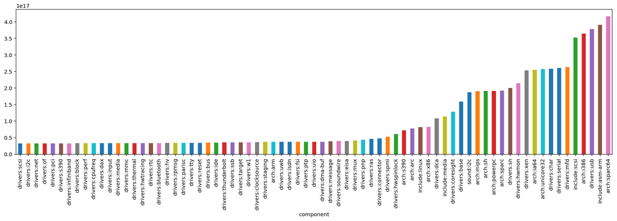

```python
age_per_component.plot.bar(figsize=[20,5]);
```

## Weitere Analysen

- [Code-Hotspots identifizieren](https://nbviewer.jupyter.org/github/feststelltaste/software-analytics/blob/master/demos/20190425_JUGH_Kassel/Code-Hotspots.ipynb)
- [Refactorings nachweisen](https://nbviewer.jupyter.org/github/feststelltaste/software-analytics/blob/master/demos/20190425_JUGH_Kassel/Refactoring.ipynb)
- [Performance-Hotspots mit jQAssistant/Neo4j finden](https://www.feststelltaste.de/mining-performance-hotspots-with-jprofiler-jqassistant-neo4j-and-pandas-part-1-the-call-graph/)
- [Code-Smells mit jQAssistant/Neo4j aufdecken](https://nbviewer.jupyter.org/github/feststelltaste/software-analytics/blob/master/demos/20190425_JUGH_Kassel/Race%20Condition%20Analysis%20Cypher%20Kernel%20Edition.ipynb)
- [Softwarerückbau mit Groovy/Tablesaw motivieren](https://nbviewer.jupyter.org/github/feststelltaste/software-analytics/blob/master/notebooks/Production%20Coverage%20Demo%20with%20Tablesaw%20and%20BeakerX.ipynb)

# Zusammenfassung

**1.** Es gibt unglaublich **viele Quellen** für Analysen  
**2.** **Problemanalysen** mit Standard-Data-Science-Werkzeugen **einfach** möglich  
**3.** Wer mehr **Software Analytics** will, bekommt auch **mehr**!

**=> vom **Problem** über die Daten zur Erkenntnis!**

## Literatur

- **Adam Tornhill: Software Design X-Rays**
- Wes McKinney: Python For Data Analysis
- Leek, Jeff: The Elements of Data Analytic Style
- Tim Menzies, Laurie Williams, Thomas Zimmermann: Perspectives on Data Science for Software Engineering

# Vielen Dank! Fragen?

**Markus Harrer**  
innoQ Deutschland GmbH

E-Mail: markus.harrer@innoq.com  
Twitter: `@feststelltaste`  
Blog: `feststelltaste.de`

[figure not shown]